# Table of Contents:

# 3. Raw Data QC:

Raw microarray data:

```
##                      1_4 1_3 1_2 1_1 2_4 2_3 2_2 2_1 3_4 3_3 3_2 3_1 4_4 4_3 4_2 4_1 5_4 5_3 5_2 5_1 6_4 6_3 6_2 6_1 7_4 7_3 7_2 7_1 8_4 8_3 8_2 8_1 9_4 9_3 9_2 9_1 10_4 10_3 10_2 10_1 11_4 11_3 11_2 11_1
## DkC.G11._17_51        14  10  28   2  11   6  15  12   9  13   6   3  13   6   9   5  19  10   8  20  12  12  10   5   8  13  15   1  18  19  17   7  16   6  18   7   10    7    4    4    7    8    2    4
## Ac_28_65_99           62  45  52   2  43  15  47  30  33  41  15   5  36  15  26   7  78  34  29  21  39  32  30  12  55  60  72  24  61  62  66  22  61  27  73  20   34   23   15    9   26   41   13   11
## Hsp27_cont.B1._17_51  24  20  37   2  26   8  19  17  19  21  11   5  21   8  11   6  44  20  20  20  26  21  18   9  20  30  32  13  37  38  27  12  33  11  30  14   21   13    8    4   19   20    8    4
## SedC.E9._131_165      36  20  70   3  24  11  30  22  29  25  14   8  27  12  17  10  51  26  27  20  35  27  25  13  29  31  26  10  60  64  36  16  45  12  31  17   31   18    8    6   24   28   13    5
## Ac_24_265_299         23  13  13   1  21   7  11   8  18  17   6   5  22  12  14   3  30  15  13  17  25  15  20   6  19  18  18   6  28  27  17   7  20   7  19   7   14    8    5    3   10   12    4    4
## Ac_3_209_243          10  10  23   1   8   2   7   7   9  11   4   3   8   4  10   4  13  11  10  15   7   6   4   5   8  16  22   5  12   9   6   4  10   5  20   7    9    4    4    3    7    8    4    3
```

# PCA results

## chip

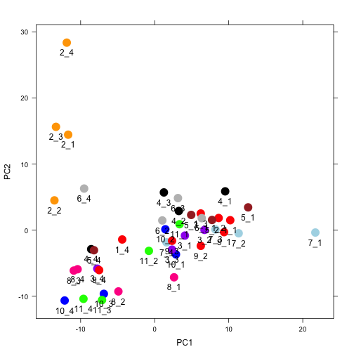

## hyb date

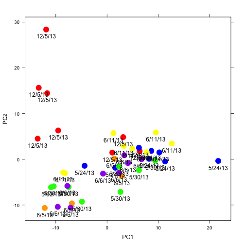

## site

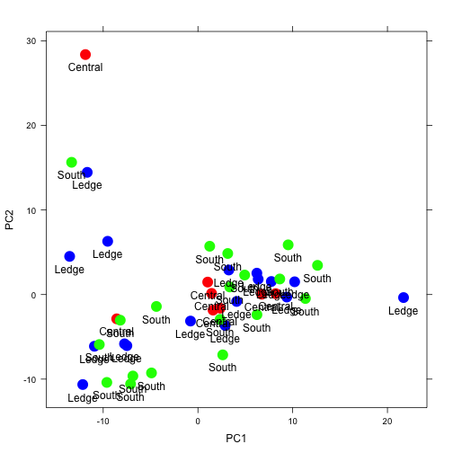

## date

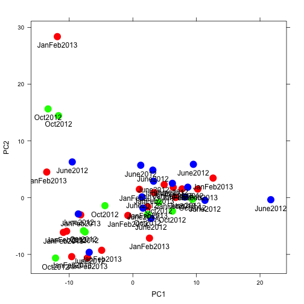

## var

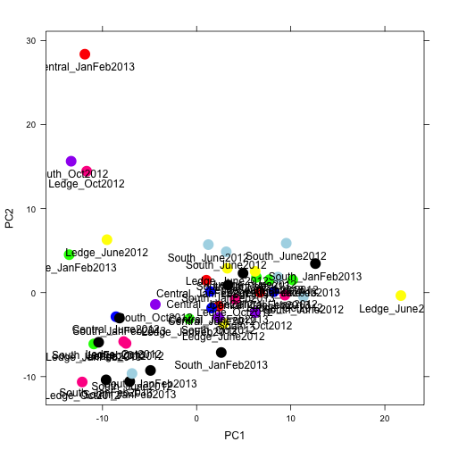

# 9. References

Izarry RA, Hobbs B, Collin F, Beazer-Barclay YD, Antonellis KJ, Scherf U, Speed TP. (2003). Exploration, normalization, and summaries of high density oligonucleotide array probe level data. Biostatistics. 2003 Apr;4(2):249-64. http://www.ncbi.nlm.nih.gov/pubmed/12925520

Ritchie, ME, Phipson, B, Wu, D, Hu, Y, Law, CW, Shi, W, and Smyth, GK (2015). limma powers differential expression analyses for RNA-sequencing and microarray studies. Nucleic Acids Research 43(7), e47. http://www.ncbi.nlm.nih.gov/pubmed/25605792

Smyth, G. K. (2004). Linear models and empirical Bayes methods for assessing differential expression in microarray experiments. Statistical Applications in Genetics and Molecular Biology, Vol. 3, No. 1, Article 3. http://www.ncbi.nlm.nih.gov/pubmed/16646809 http://www.statsci.org/smyth/pubs/ebayes.pdf

R-Bioconductor: http://www.bioconductor.org/

limma: http://www.bioconductor.org/packages/release/bioc/vignettes/limma/inst/doc/usersguide.pdf